# Motor Trend Data Analysis

Regression Models Course Project

Ray Qiu

October 22, 2015

## Executive Summary

#### Motor Trend, a magazine about the automobile industry, wants you to look at a data set of a collection of cars, they are interested in exploring the relationship between a set of variables and miles per gallon (MPG) (outcome). They are particularly interested in the following two questions:

- “Is an automatic or manual transmission better for MPG”
- “Quantify the MPG difference between automatic and manual transmissions”

#### Load required R libraries

#### Load the mtcars data and perform some basic exploratory data analysis.

```r
data(mtcars)
# Convert cyl, am and gear to factors
mtcars$cyl <- as.factor(mtcars$cyl)
mtcars$am <- factor(mtcars$am, labels = c("automatic", "manual"))
mtcars$gear <- as.factor(mtcars$gear)
```

#### Some simple plots to show the relationships between mpg and manual/automatic transmission.

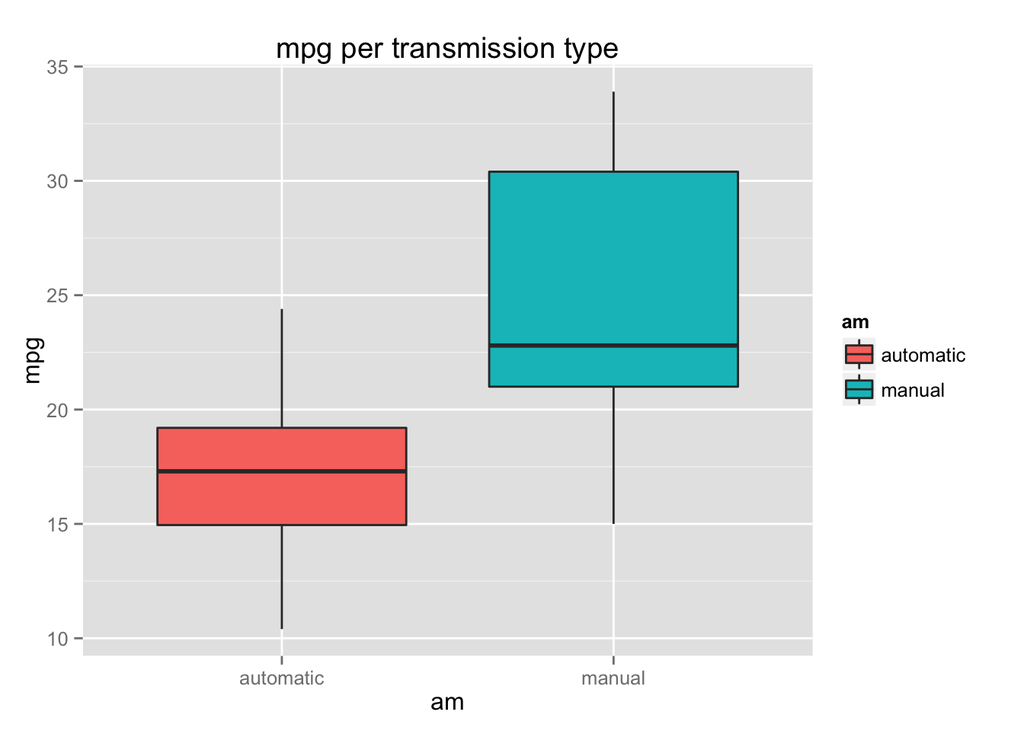

```r
ggplot(mtcars, aes(x = am, y = mpg)) +
    ggtitle("mpg per transmission type") +
    geom_boxplot(aes(fill = am))
```

#### Answer to Question #1: Manual transmission is better than automatic transmission for MPG.

#### First, build a regression model for MPG per transmission type and see how fit it is.

```r
fit <- lm(mpg ~ am, data = mtcars)
summary(fit)
```

```
##
## Call:
## lm(formula = mpg ~ am, data = mtcars)
##
## Residuals:
##     Min      1Q  Median      3Q     Max
## -9.3923 -3.0923 -0.2974  3.2439  9.5077
##
## Coefficients:
##             Estimate Std. Error t value Pr(>|t|)
## (Intercept)   17.147      1.125  15.247 1.13e-15 ***
## ammanual       7.245      1.764   4.106 0.000285 ***
## ---
## Signif. codes:  0 '***' 0.001 '**' 0.01 '*' 0.05 '.' 0.1 ' ' 1
##
## Residual standard error: 4.902 on 30 degrees of freedom
## Multiple R-squared:  0.3598, Adjusted R-squared:  0.3385
## F-statistic: 16.86 on 1 and 30 DF,  p-value: 0.000285
```

We can see that “Adjusted R-squared” is only 0.3385, far from 1, so that this model is not a good fit for the data.

#### Now, let’s try to see what other variables should be included in the model

```r
fit2 <- lm(mpg ~ ., data = mtcars)
anova(fit2)
```

```
## Analysis of Variance Table
##
## Response: mpg
##           Df Sum Sq Mean Sq F value    Pr(>F)
## cyl        2 824.78  412.39 60.2490 5.953e-09 ***
## disp       1  57.64   57.64  8.4214  0.009139 **
## hp         1  18.50   18.50  2.7031  0.116598
## drat       1  11.91   11.91  1.7407  0.202734
## wt         1  55.79   55.79  8.1503  0.010134 *
## qsec       1   1.52    1.52  0.2227  0.642342
## vs         1   0.30    0.30  0.0441  0.835841
## am         1  16.57   16.57  2.4203  0.136271
## gear       2   5.02    2.51  0.3668  0.697741
## carb       1   3.95    3.95  0.5771  0.456767
## Residuals 19 130.05    6.84
## ---
## Signif. codes:  0 '***' 0.001 '**' 0.01 '*' 0.05 '.' 0.1 ' ' 1
```

```r
fit3 <- lm(mpg ~ cyl + disp + hp + wt + am, data = mtcars)
summary(fit3)
```

```
##
## Call:
## lm(formula = mpg ~ cyl + disp + hp + wt + am, data = mtcars)
##
## Residuals:
##     Min      1Q  Median      3Q     Max
## -3.9374 -1.3347 -0.3903  1.1910  5.0757
##
## Coefficients:
##              Estimate Std. Error t value Pr(>|t|)
## (Intercept) 33.864276   2.695416  12.564 2.67e-12 ***
## cyl6        -3.136067   1.469090  -2.135   0.0428 *
## cyl8        -2.717781   2.898149  -0.938   0.3573
## disp         0.004088   0.012767   0.320   0.7515
## hp          -0.032480   0.013983  -2.323   0.0286 *
## wt          -2.738695   1.175978  -2.329   0.0282 *
## ammanual     1.806099   1.421079   1.271   0.2155
## ---
## Signif. codes:  0 '***' 0.001 '**' 0.01 '*' 0.05 '.' 0.1 ' ' 1
##
## Residual standard error: 2.453 on 25 degrees of freedom
## Multiple R-squared:  0.8664, Adjusted R-squared:  0.8344
## F-statistic: 27.03 on 6 and 25 DF,  p-value: 8.861e-10
```

Now, the “Adjusted R-squared” is 0.8344, which we believe is a good fit model for the data.

#### Answer to Question #2: Cars with Manual transmission get better MPG than Automatic transmission, and the coefficient is 1.806099, adjusted by cyl, disp, hp, and wt.

## Appendix: Plots for the models

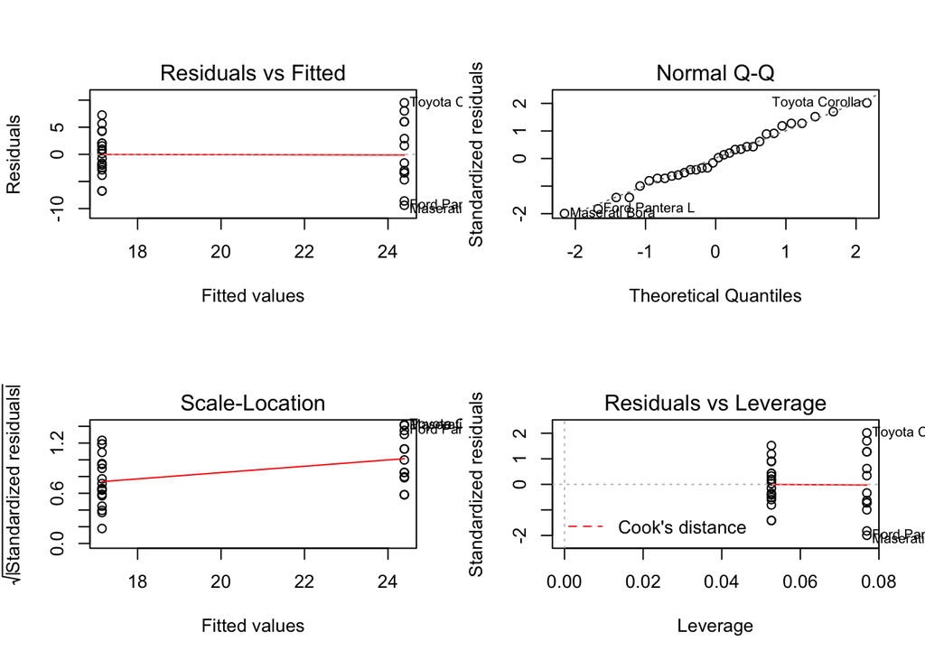

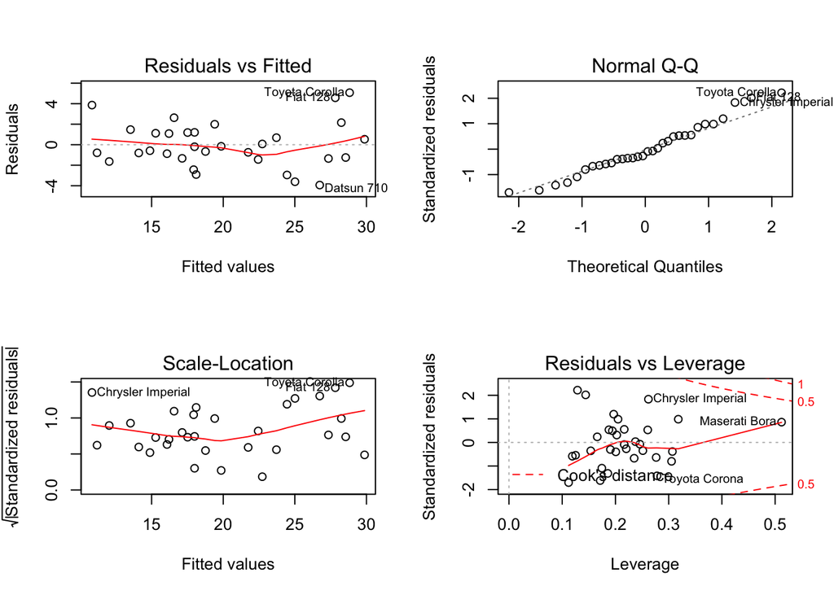